# Bike Sharing Data in Washington D.C.

# Exploratory Data Analysis (EDA) and Visualization

```python
# Run this cell to set up your notebook.  Make sure ds-ua-112_utils.py is in this assignment's folder
import seaborn as sns
import csv
import numpy as np
import pandas as pd
import matplotlib.pyplot as plt
import zipfile
from IPython.display import Image
from pathlib import Path
import ds_ua_112_utils

# Default plot configurations
%matplotlib inline
plt.rcParams['figure.figsize'] = (16,8)
plt.rcParams['figure.dpi'] = 150
sns.set()

from IPython.display import display, Latex, Markdown
```

## Loading Bike Sharing Data

The data we are exploring is data on bike sharing in Washington D.C.

The variables in this data frame are defined as:

| Variable | Description |
| --- | --- |
| instant | record index |
| dteday | date |
| season | 1. spring 2. summer 3. fall 4. winter |
| yr | year (0: 2011, 1:2012) |
| mnth | month ( 1 to 12) |
| hr | hour (0 to 23) |
| holiday | whether day is holiday or not |
| weekday | day of the week |
| workingday | if day is neither weekend nor holiday |
| weathersit | 1. clear or partly cloudy 2. mist and clouds 3. light snow or rain 4. heavy rain or snow |
| temp | normalized temperature in Celsius (divided by 41) |
| atemp | normalized "feels-like" temperature in Celsius (divided by 50) |
| hum | normalized percent humidity (divided by 100) |
| windspeed | normalized wind speed (divided by 67) |
| casual | count of casual users |
| registered | count of registered users |
| cnt | count of total rental bikes including casual and registered |

### Download the Data

```python
# Run this cell to download the data.  No further action is needed

data_url = 'https://cims.nyu.edu/~policast/bikeshare.zip'
file_name = 'data.zip'
data_dir = '.'

dest_path = ds_ua_112_utils.fetch_and_cache(data_url=data_url, data_dir=data_dir, file=file_name)
print('Saved at {}'.format(dest_path))

zipped_data = zipfile.ZipFile(dest_path, 'r')

data_dir = Path('data')
zipped_data.extractall(data_dir)


print("Extracted Files:")
for f in data_dir.glob("*"):
    print("\t",f)
```

```
Using version already downloaded: Fri Oct 11 14:48:21 2019
MD5 hash of file: fe4d1444ec7354d027a220f46dde42b1
Saved at data.zip
Extracted Files:
	 data/bikeshare.txt
	 data/data
```

### Examining the file contents

Let's check the file format.

```python
for line in ds_ua_112_utils.head(data_dir/'bikeshare.txt'):
    print(line,end="")
```

```
instant,dteday,season,yr,mnth,hr,holiday,weekday,workingday,weathersit,temp,atemp,hum,windspeed,casual,registered,cnt
1,2011-01-01,1,0,1,0,0,6,0,1,0.24,0.2879,0.81,0,3,13,16
2,2011-01-01,1,0,1,1,0,6,0,1,0.22,0.2727,0.8,0,8,32,40
3,2011-01-01,1,0,1,2,0,6,0,1,0.22,0.2727,0.8,0,5,27,32
4,2011-01-01,1,0,1,3,0,6,0,1,0.24,0.2879,0.75,0,3,10,13
```

### Size

Is the file big? How many records do we expect to find?

```python
print("Size:", (data_dir/"bikeshare.txt").stat().st_size, "bytes")
print("Line Count:", ds_ua_112_utils.line_count(data_dir/"bikeshare.txt"), "lines")
```

```
Size: 1156736 bytes
Line Count: 17380 lines
```

### Loading the data

The following code loads the data into a Pandas DataFrame.

```python
bike = pd.read_csv(data_dir/'bikeshare.txt')
bike.head()
```

|  | instant | dteday | season | yr | mnth | hr | holiday | weekday | workingday | weathersit | temp | atemp | hum | windspeed | casual | registered | cnt |
| --- | --- | --- | --- | --- | --- | --- | --- | --- | --- | --- | --- | --- | --- | --- | --- | --- | --- |
| 0 | 1 | 2011-01-01 | 1 | 0 | 1 | 0 | 0 | 6 | 0 | 1 | 0.24 | 0.2879 | 0.81 | 0.0 | 3 | 13 | 16 |
| 1 | 2 | 2011-01-01 | 1 | 0 | 1 | 1 | 0 | 6 | 0 | 1 | 0.22 | 0.2727 | 0.80 | 0.0 | 8 | 32 | 40 |
| 2 | 3 | 2011-01-01 | 1 | 0 | 1 | 2 | 0 | 6 | 0 | 1 | 0.22 | 0.2727 | 0.80 | 0.0 | 5 | 27 | 32 |
| 3 | 4 | 2011-01-01 | 1 | 0 | 1 | 3 | 0 | 6 | 0 | 1 | 0.24 | 0.2879 | 0.75 | 0.0 | 3 | 10 | 13 |
| 4 | 5 | 2011-01-01 | 1 | 0 | 1 | 4 | 0 | 6 | 0 | 1 | 0.24 | 0.2879 | 0.75 | 0.0 | 0 | 1 | 1 |

Below, we show the shape of the file. You should see that the size of the dataframe matches the number of lines in the file, minus the header row.

```python
bike.shape
```

```
(17379, 17)
```

## Data Preparation

A few of the variables that are numeric/integer actually encode categorical data. These include `holiday`, `weekday`, `workingday`, and `weathersit`. In the following problem, we will convert these four variables to strings specifying the categories. In particular, use 3-letter labels (`Sun`, `Mon`, `Tue`, `Wed`, `Thu`, `Fri`, and `Sat`) for `weekday`. We will simply use `yes`/`no` for `holiday` and `workingday`.

Here we will *mutate* the data frame, **overwriting the corresponding variables in the data frame.** However, our notebook will effectively document this in-place data transformation for future readers.

### Decoding `weekday`, `workingday`, and `weathersit`)

Let's decode the `holiday`, `weekday`, `workingday`, and `weathersit` fields:

1. `holiday`: Convert to `yes` and `no`. Hint: There are fewer holidays...
2. `weekday`: Mutate the `'weekday'` column to use the 3-letter label (`'Sun'`, `'Mon'`, `'Tue'`, `'Wed'`, `'Thu'`, `'Fri'`, and `'Sat'` ...) instead of its current numerical values. Assume `0` corresponds to `Sun`, `1` to `Mon` and so on.
3. `workingday`: Convert to `yes` and `no`.
4. `weathersit`: Replace each value with one of `Clear`, `Mist`, `Light`, or `Heavy`.

```python
bike = bike.replace({'holiday':0}, 'no').replace({'holiday':1}, 'yes')
bike = bike.replace({'weekday':0}, 'Sun').replace({'weekday':1}, 'Mon').replace({'weekday':2}, 'Tue')
bike = bike.replace({'weekday':3}, 'Wed').replace({'weekday':4}, 'Thu').replace({'weekday':5}, 'Fri').replace({'weekday':6}, 'Sat')
bike = bike.replace({'workingday':0}, 'no').replace({'workingday':1}, 'yes')
bike = bike.replace({'weathersit':1}, 'Clear').replace({'weathersit':2}, 'Mist')
bike = bike.replace({'weathersit':3}, 'Light').replace({'weathersit':4}, 'Heavy')
bike
```

|  | instant | dteday | season | yr | mnth | hr | holiday | weekday | workingday | weathersit | temp | atemp | hum | windspeed | casual | registered | cnt |
| --- | --- | --- | --- | --- | --- | --- | --- | --- | --- | --- | --- | --- | --- | --- | --- | --- | --- |
| 0 | 1 | 2011-01-01 | 1 | 0 | 1 | 0 | no | Sat | no | Clear | 0.24 | 0.2879 | 0.81 | 0.0000 | 3 | 13 | 16 |
| 1 | 2 | 2011-01-01 | 1 | 0 | 1 | 1 | no | Sat | no | Clear | 0.22 | 0.2727 | 0.80 | 0.0000 | 8 | 32 | 40 |
| 2 | 3 | 2011-01-01 | 1 | 0 | 1 | 2 | no | Sat | no | Clear | 0.22 | 0.2727 | 0.80 | 0.0000 | 5 | 27 | 32 |
| 3 | 4 | 2011-01-01 | 1 | 0 | 1 | 3 | no | Sat | no | Clear | 0.24 | 0.2879 | 0.75 | 0.0000 | 3 | 10 | 13 |
| 4 | 5 | 2011-01-01 | 1 | 0 | 1 | 4 | no | Sat | no | Clear | 0.24 | 0.2879 | 0.75 | 0.0000 | 0 | 1 | 1 |
| 5 | 6 | 2011-01-01 | 1 | 0 | 1 | 5 | no | Sat | no | Mist | 0.24 | 0.2576 | 0.75 | 0.0896 | 0 | 1 | 1 |
| 6 | 7 | 2011-01-01 | 1 | 0 | 1 | 6 | no | Sat | no | Clear | 0.22 | 0.2727 | 0.80 | 0.0000 | 2 | 0 | 2 |
| 7 | 8 | 2011-01-01 | 1 | 0 | 1 | 7 | no | Sat | no | Clear | 0.20 | 0.2576 | 0.86 | 0.0000 | 1 | 2 | 3 |
| 8 | 9 | 2011-01-01 | 1 | 0 | 1 | 8 | no | Sat | no | Clear | 0.24 | 0.2879 | 0.75 | 0.0000 | 1 | 7 | 8 |
| 9 | 10 | 2011-01-01 | 1 | 0 | 1 | 9 | no | Sat | no | Clear | 0.32 | 0.3485 | 0.76 | 0.0000 | 8 | 6 | 14 |
| 10 | 11 | 2011-01-01 | 1 | 0 | 1 | 10 | no | Sat | no | Clear | 0.38 | 0.3939 | 0.76 | 0.2537 | 12 | 24 | 36 |
| 11 | 12 | 2011-01-01 | 1 | 0 | 1 | 11 | no | Sat | no | Clear | 0.36 | 0.3333 | 0.81 | 0.2836 | 26 | 30 | 56 |
| 12 | 13 | 2011-01-01 | 1 | 0 | 1 | 12 | no | Sat | no | Clear | 0.42 | 0.4242 | 0.77 | 0.2836 | 29 | 55 | 84 |
| 13 | 14 | 2011-01-01 | 1 | 0 | 1 | 13 | no | Sat | no | Mist | 0.46 | 0.4545 | 0.72 | 0.2985 | 47 | 47 | 94 |
| 14 | 15 | 2011-01-01 | 1 | 0 | 1 | 14 | no | Sat | no | Mist | 0.46 | 0.4545 | 0.72 | 0.2836 | 35 | 71 | 106 |
| 15 | 16 | 2011-01-01 | 1 | 0 | 1 | 15 | no | Sat | no | Mist | 0.44 | 0.4394 | 0.77 | 0.2985 | 40 | 70 | 110 |
| 16 | 17 | 2011-01-01 | 1 | 0 | 1 | 16 | no | Sat | no | Mist | 0.42 | 0.4242 | 0.82 | 0.2985 | 41 | 52 | 93 |
| 17 | 18 | 2011-01-01 | 1 | 0 | 1 | 17 | no | Sat | no | Mist | 0.44 | 0.4394 | 0.82 | 0.2836 | 15 | 52 | 67 |
| 18 | 19 | 2011-01-01 | 1 | 0 | 1 | 18 | no | Sat | no | Light | 0.42 | 0.4242 | 0.88 | 0.2537 | 9 | 26 | 35 |
| 19 | 20 | 2011-01-01 | 1 | 0 | 1 | 19 | no | Sat | no | Light | 0.42 | 0.4242 | 0.88 | 0.2537 | 6 | 31 | 37 |
| 20 | 21 | 2011-01-01 | 1 | 0 | 1 | 20 | no | Sat | no | Mist | 0.40 | 0.4091 | 0.87 | 0.2537 | 11 | 25 | 36 |
| 21 | 22 | 2011-01-01 | 1 | 0 | 1 | 21 | no | Sat | no | Mist | 0.40 | 0.4091 | 0.87 | 0.1940 | 3 | 31 | 34 |
| 22 | 23 | 2011-01-01 | 1 | 0 | 1 | 22 | no | Sat | no | Mist | 0.40 | 0.4091 | 0.94 | 0.2239 | 11 | 17 | 28 |
| 23 | 24 | 2011-01-01 | 1 | 0 | 1 | 23 | no | Sat | no | Mist | 0.46 | 0.4545 | 0.88 | 0.2985 | 15 | 24 | 39 |
| 24 | 25 | 2011-01-02 | 1 | 0 | 1 | 0 | no | Sun | no | Mist | 0.46 | 0.4545 | 0.88 | 0.2985 | 4 | 13 | 17 |
| 25 | 26 | 2011-01-02 | 1 | 0 | 1 | 1 | no | Sun | no | Mist | 0.44 | 0.4394 | 0.94 | 0.2537 | 1 | 16 | 17 |
| 26 | 27 | 2011-01-02 | 1 | 0 | 1 | 2 | no | Sun | no | Mist | 0.42 | 0.4242 | 1.00 | 0.2836 | 1 | 8 | 9 |
| 27 | 28 | 2011-01-02 | 1 | 0 | 1 | 3 | no | Sun | no | Mist | 0.46 | 0.4545 | 0.94 | 0.1940 | 2 | 4 | 6 |
| 28 | 29 | 2011-01-02 | 1 | 0 | 1 | 4 | no | Sun | no | Mist | 0.46 | 0.4545 | 0.94 | 0.1940 | 2 | 1 | 3 |
| 29 | 30 | 2011-01-02 | 1 | 0 | 1 | 6 | no | Sun | no | Light | 0.42 | 0.4242 | 0.77 | 0.2985 | 0 | 2 | 2 |
| ... | ... | ... | ... | ... | ... | ... | ... | ... | ... | ... | ... | ... | ... | ... | ... | ... | ... |
| 17349 | 17350 | 2012-12-30 | 1 | 1 | 12 | 18 | no | Sun | no | Mist | 0.24 | 0.2121 | 0.44 | 0.2985 | 12 | 113 | 125 |
| 17350 | 17351 | 2012-12-30 | 1 | 1 | 12 | 19 | no | Sun | no | Clear | 0.34 | 0.3636 | 0.61 | 0.0000 | 16 | 86 | 102 |
| 17351 | 17352 | 2012-12-30 | 1 | 1 | 12 | 20 | no | Sun | no | Clear | 0.22 | 0.1970 | 0.47 | 0.3284 | 9 | 63 | 72 |
| 17352 | 17353 | 2012-12-30 | 1 | 1 | 12 | 21 | no | Sun | no | Clear | 0.20 | 0.2121 | 0.51 | 0.1642 | 5 | 42 | 47 |
| 17353 | 17354 | 2012-12-30 | 1 | 1 | 12 | 22 | no | Sun | no | Clear | 0.20 | 0.1970 | 0.55 | 0.1940 | 6 | 30 | 36 |
| 17354 | 17355 | 2012-12-30 | 1 | 1 | 12 | 23 | no | Sun | no | Clear | 0.20 | 0.1970 | 0.51 | 0.2239 | 10 | 39 | 49 |
| 17355 | 17356 | 2012-12-31 | 1 | 1 | 12 | 0 | no | Mon | yes | Clear | 0.18 | 0.1818 | 0.55 | 0.1940 | 4 | 30 | 34 |
| 17356 | 17357 | 2012-12-31 | 1 | 1 | 12 | 1 | no | Mon | yes | Clear | 0.18 | 0.1818 | 0.55 | 0.1940 | 6 | 13 | 19 |
| 17357 | 17358 | 2012-12-31 | 1 | 1 | 12 | 2 | no | Mon | yes | Clear | 0.16 | 0.1667 | 0.59 | 0.1642 | 3 | 8 | 11 |
| 17358 | 17359 | 2012-12-31 | 1 | 1 | 12 | 3 | no | Mon | yes | Clear | 0.16 | 0.1818 | 0.59 | 0.1045 | 0 | 1 | 1 |
| 17359 | 17360 | 2012-12-31 | 1 | 1 | 12 | 4 | no | Mon | yes | Clear | 0.14 | 0.1667 | 0.69 | 0.1045 | 0 | 3 | 3 |
| 17360 | 17361 | 2012-12-31 | 1 | 1 | 12 | 5 | no | Mon | yes | Clear | 0.16 | 0.1515 | 0.64 | 0.1940 | 0 | 9 | 9 |
| 17361 | 17362 | 2012-12-31 | 1 | 1 | 12 | 6 | no | Mon | yes | Clear | 0.16 | 0.1667 | 0.64 | 0.1642 | 0 | 40 | 40 |
| 17362 | 17363 | 2012-12-31 | 1 | 1 | 12 | 7 | no | Mon | yes | Clear | 0.16 | 0.1818 | 0.64 | 0.1343 | 2 | 83 | 85 |
| 17363 | 17364 | 2012-12-31 | 1 | 1 | 12 | 8 | no | Mon | yes | Clear | 0.14 | 0.1515 | 0.69 | 0.1343 | 9 | 187 | 196 |
| 17364 | 17365 | 2012-12-31 | 1 | 1 | 12 | 9 | no | Mon | yes | Mist | 0.18 | 0.2121 | 0.64 | 0.1045 | 13 | 144 | 157 |
| 17365 | 17366 | 2012-12-31 | 1 | 1 | 12 | 10 | no | Mon | yes | Mist | 0.20 | 0.2121 | 0.69 | 0.1343 | 33 | 87 | 120 |
| 17366 | 17367 | 2012-12-31 | 1 | 1 | 12 | 11 | no | Mon | yes | Mist | 0.22 | 0.2273 | 0.60 | 0.1940 | 43 | 114 | 157 |
| 17367 | 17368 | 2012-12-31 | 1 | 1 | 12 | 12 | no | Mon | yes | Mist | 0.24 | 0.2273 | 0.56 | 0.1940 | 52 | 172 | 224 |
| 17368 | 17369 | 2012-12-31 | 1 | 1 | 12 | 13 | no | Mon | yes | Mist | 0.26 | 0.2576 | 0.44 | 0.1642 | 38 | 165 | 203 |
| 17369 | 17370 | 2012-12-31 | 1 | 1 | 12 | 14 | no | Mon | yes | Mist | 0.28 | 0.2727 | 0.45 | 0.2239 | 62 | 185 | 247 |
| 17370 | 17371 | 2012-12-31 | 1 | 1 | 12 | 15 | no | Mon | yes | Mist | 0.28 | 0.2879 | 0.45 | 0.1343 | 69 | 246 | 315 |
| 17371 | 17372 | 2012-12-31 | 1 | 1 | 12 | 16 | no | Mon | yes | Mist | 0.26 | 0.2576 | 0.48 | 0.1940 | 30 | 184 | 214 |
| 17372 | 17373 | 2012-12-31 | 1 | 1 | 12 | 17 | no | Mon | yes | Mist | 0.26 | 0.2879 | 0.48 | 0.0896 | 14 | 150 | 164 |
| 17373 | 17374 | 2012-12-31 | 1 | 1 | 12 | 18 | no | Mon | yes | Mist | 0.26 | 0.2727 | 0.48 | 0.1343 | 10 | 112 | 122 |
| 17374 | 17375 | 2012-12-31 | 1 | 1 | 12 | 19 | no | Mon | yes | Mist | 0.26 | 0.2576 | 0.60 | 0.1642 | 11 | 108 | 119 |
| 17375 | 17376 | 2012-12-31 | 1 | 1 | 12 | 20 | no | Mon | yes | Mist | 0.26 | 0.2576 | 0.60 | 0.1642 | 8 | 81 | 89 |
| 17376 | 17377 | 2012-12-31 | 1 | 1 | 12 | 21 | no | Mon | yes | Clear | 0.26 | 0.2576 | 0.60 | 0.1642 | 7 | 83 | 90 |
| 17377 | 17378 | 2012-12-31 | 1 | 1 | 12 | 22 | no | Mon | yes | Clear | 0.26 | 0.2727 | 0.56 | 0.1343 | 13 | 48 | 61 |
| 17378 | 17379 | 2012-12-31 | 1 | 1 | 12 | 23 | no | Mon | yes | Clear | 0.26 | 0.2727 | 0.65 | 0.1343 | 12 | 37 | 49 |

17379 rows × 17 columns

### Holidays

How many entries in the data correspond to holidays?

```python
num_holidays = bike['holiday'].value_counts()['yes']

num_holidays
```

```
500
```

#### Computing Daily Total Counts

The granularity of this data is at the hourly level. However, for some of the analysis we will also want to compute daily statistics. In particular, in the next few questions we will be analyzing the daily number of registered and unregistered users.

Let's construct a data frame with the following columns:

- `casual`: total number of casual riders for each day
- `registered`: total number of registered riders for each day
- `workingday`: whether that day is a working day or not (`yes` or `no`)

```python
daily_counts = pd.DataFrame({'casual':bike['casual'], 'registered': bike['registered'] , 'workingday':bike['workingday'], 'dteday':bike['dteday']})
daily_counts = daily_counts.groupby('dteday').agg({'casual' : 'sum', 'registered' : 'sum', 'workingday' : 'first'})
daily_counts
```

| dteday | casual | registered | workingday |
| --- | --- | --- | --- |
| 2011-01-01 | 331 | 654 | no |
| 2011-01-02 | 131 | 670 | no |
| 2011-01-03 | 120 | 1229 | yes |
| 2011-01-04 | 108 | 1454 | yes |
| 2011-01-05 | 82 | 1518 | yes |
| 2011-01-06 | 88 | 1518 | yes |
| 2011-01-07 | 148 | 1362 | yes |
| 2011-01-08 | 68 | 891 | no |
| 2011-01-09 | 54 | 768 | no |
| 2011-01-10 | 41 | 1280 | yes |
| 2011-01-11 | 43 | 1220 | yes |
| 2011-01-12 | 25 | 1137 | yes |
| 2011-01-13 | 38 | 1368 | yes |
| 2011-01-14 | 54 | 1367 | yes |
| 2011-01-15 | 222 | 1026 | no |
| 2011-01-16 | 251 | 953 | no |
| 2011-01-17 | 117 | 883 | no |
| 2011-01-18 | 9 | 674 | yes |
| 2011-01-19 | 78 | 1572 | yes |
| 2011-01-20 | 83 | 1844 | yes |
| 2011-01-21 | 75 | 1468 | yes |
| 2011-01-22 | 93 | 888 | no |
| 2011-01-23 | 150 | 836 | no |
| 2011-01-24 | 86 | 1330 | yes |
| 2011-01-25 | 186 | 1799 | yes |
| 2011-01-26 | 34 | 472 | yes |
| 2011-01-27 | 15 | 416 | yes |
| 2011-01-28 | 38 | 1129 | yes |
| 2011-01-29 | 123 | 975 | no |
| 2011-01-30 | 140 | 956 | no |
| ... | ... | ... | ... |
| 2012-12-02 | 892 | 3757 | no |
| 2012-12-03 | 555 | 5679 | yes |
| 2012-12-04 | 551 | 6055 | yes |
| 2012-12-05 | 331 | 5398 | yes |
| 2012-12-06 | 340 | 5035 | yes |
| 2012-12-07 | 349 | 4659 | yes |
| 2012-12-08 | 1153 | 4429 | no |
| 2012-12-09 | 441 | 2787 | no |
| 2012-12-10 | 329 | 4841 | yes |
| 2012-12-11 | 282 | 5219 | yes |
| 2012-12-12 | 310 | 5009 | yes |
| 2012-12-13 | 425 | 5107 | yes |
| 2012-12-14 | 429 | 5182 | yes |
| 2012-12-15 | 767 | 4280 | no |
| 2012-12-16 | 538 | 3248 | no |
| 2012-12-17 | 212 | 4373 | yes |
| 2012-12-18 | 433 | 5124 | yes |
| 2012-12-19 | 333 | 4934 | yes |
| 2012-12-20 | 314 | 3814 | yes |
| 2012-12-21 | 221 | 3402 | yes |
| 2012-12-22 | 205 | 1544 | no |
| 2012-12-23 | 408 | 1379 | no |
| 2012-12-24 | 174 | 746 | yes |
| 2012-12-25 | 440 | 573 | no |
| 2012-12-26 | 9 | 432 | yes |
| 2012-12-27 | 247 | 1867 | yes |
| 2012-12-28 | 644 | 2451 | yes |
| 2012-12-29 | 159 | 1182 | no |
| 2012-12-30 | 364 | 1432 | no |
| 2012-12-31 | 439 | 2290 | yes |

731 rows × 3 columns

## Exploring the Distribution of Riders

Let's begin by comparing the distribution of the daily counts of casual and registered riders.

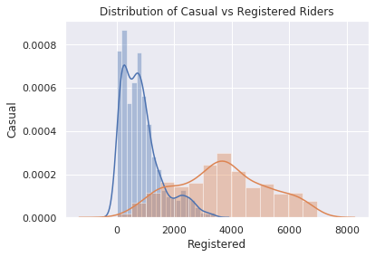

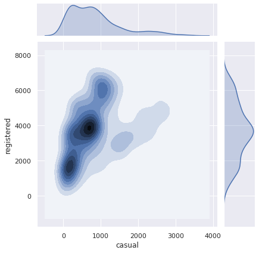

```python
x = sns.distplot(daily_counts['casual'])
x = sns.distplot(daily_counts['registered'])
x.set_ylabel("Casual")
x.set_xlabel("Registered")
x.set_title("Distribution of Casual vs Registered Riders");
sns.jointplot(x="casual", y="registered", data=daily_counts, kind="kde")
```